# Flights Dataset Exploration

## Preliminary Wrangling

> This dataset reports flights in the United States, including carriers, arrival and departure delays, and reasons for delays, 2008. This dataset consist of slightly more 7 million rows and 29 columns.

```python
# import all packages and set plots to be embedded inline
import numpy as np
import pandas as pd
import matplotlib.pyplot as plt
import seaborn as sb

%matplotlib inline
```

```python
df = pd.read_csv('2008.csv.bz2')
```

```python
df.shape
```

```
(7009728, 29)
```

```python
# data view
df.head()
```

|  | Year | Month | DayofMonth | DayOfWeek | DepTime | CRSDepTime | ArrTime | CRSArrTime | UniqueCarrier | FlightNum | ... | TaxiIn | TaxiOut | Cancelled | CancellationCode | Diverted | CarrierDelay | WeatherDelay | NASDelay | SecurityDelay | LateAircraftDelay |
| --- | --- | --- | --- | --- | --- | --- | --- | --- | --- | --- | --- | --- | --- | --- | --- | --- | --- | --- | --- | --- | --- |
| 0 | 2008 | 1 | 3 | 4 | 2003.0 | 1955 | 2211.0 | 2225 | WN | 335 | ... | 4.0 | 8.0 | 0 | NaN | 0 | NaN | NaN | NaN | NaN | NaN |
| 1 | 2008 | 1 | 3 | 4 | 754.0 | 735 | 1002.0 | 1000 | WN | 3231 | ... | 5.0 | 10.0 | 0 | NaN | 0 | NaN | NaN | NaN | NaN | NaN |
| 2 | 2008 | 1 | 3 | 4 | 628.0 | 620 | 804.0 | 750 | WN | 448 | ... | 3.0 | 17.0 | 0 | NaN | 0 | NaN | NaN | NaN | NaN | NaN |
| 3 | 2008 | 1 | 3 | 4 | 926.0 | 930 | 1054.0 | 1100 | WN | 1746 | ... | 3.0 | 7.0 | 0 | NaN | 0 | NaN | NaN | NaN | NaN | NaN |
| 4 | 2008 | 1 | 3 | 4 | 1829.0 | 1755 | 1959.0 | 1925 | WN | 3920 | ... | 3.0 | 10.0 | 0 | NaN | 0 | 2.0 | 0.0 | 0.0 | 0.0 | 32.0 |

5 rows × 29 columns

```python
# describtive statistic
df.describe()
```

|  | Year | Month | DayofMonth | DayOfWeek | DepTime | CRSDepTime | ArrTime | CRSArrTime | FlightNum | ActualElapsedTime | ... | Distance | TaxiIn | TaxiOut | Cancelled | Diverted | CarrierDelay | WeatherDelay | NASDelay | SecurityDelay | LateAircraftDelay |
| --- | --- | --- | --- | --- | --- | --- | --- | --- | --- | --- | --- | --- | --- | --- | --- | --- | --- | --- | --- | --- | --- |
| count | 7009728.0 | 7.009728e+06 | 7.009728e+06 | 7.009728e+06 | 6.873482e+06 | 7.009728e+06 | 6.858079e+06 | 7.009728e+06 | 7.009728e+06 | 6.855029e+06 | ... | 7.009728e+06 | 6.858079e+06 | 6.872670e+06 | 7.009728e+06 | 7.009728e+06 | 1.524735e+06 | 1.524735e+06 | 1.524735e+06 | 1.524735e+06 | 1.524735e+06 |
| mean | 2008.0 | 6.375130e+00 | 1.572801e+01 | 3.924182e+00 | 1.333830e+03 | 1.326086e+03 | 1.481258e+03 | 1.494801e+03 | 2.224200e+03 | 1.273224e+02 | ... | 7.263870e+02 | 6.860852e+00 | 1.645305e+01 | 1.960618e-02 | 2.463006e-03 | 1.577206e+01 | 3.039031e+00 | 1.716462e+01 | 7.497434e-02 | 2.077098e+01 |
| std | 0.0 | 3.406737e+00 | 8.797068e+00 | 1.988259e+00 | 4.780689e+02 | 4.642509e+02 | 5.052251e+02 | 4.826728e+02 | 1.961716e+03 | 7.018731e+01 | ... | 5.621018e+02 | 4.933649e+00 | 1.133280e+01 | 1.386426e-01 | 4.956753e-02 | 4.009912e+01 | 1.950287e+01 | 3.189495e+01 | 1.837940e+00 | 3.925964e+01 |
| min | 2008.0 | 1.000000e+00 | 1.000000e+00 | 1.000000e+00 | 1.000000e+00 | 0.000000e+00 | 1.000000e+00 | 0.000000e+00 | 1.000000e+00 | 1.200000e+01 | ... | 1.100000e+01 | 0.000000e+00 | 0.000000e+00 | 0.000000e+00 | 0.000000e+00 | 0.000000e+00 | 0.000000e+00 | 0.000000e+00 | 0.000000e+00 | 0.000000e+00 |
| 25% | 2008.0 | 3.000000e+00 | 8.000000e+00 | 2.000000e+00 | 9.280000e+02 | 9.250000e+02 | 1.107000e+03 | 1.115000e+03 | 6.220000e+02 | 7.700000e+01 | ... | 3.250000e+02 | 4.000000e+00 | 1.000000e+01 | 0.000000e+00 | 0.000000e+00 | 0.000000e+00 | 0.000000e+00 | 0.000000e+00 | 0.000000e+00 | 0.000000e+00 |
| 50% | 2008.0 | 6.000000e+00 | 1.600000e+01 | 4.000000e+00 | 1.325000e+03 | 1.320000e+03 | 1.512000e+03 | 1.517000e+03 | 1.571000e+03 | 1.100000e+02 | ... | 5.810000e+02 | 6.000000e+00 | 1.400000e+01 | 0.000000e+00 | 0.000000e+00 | 0.000000e+00 | 0.000000e+00 | 6.000000e+00 | 0.000000e+00 | 0.000000e+00 |
| 75% | 2008.0 | 9.000000e+00 | 2.300000e+01 | 6.000000e+00 | 1.728000e+03 | 1.715000e+03 | 1.909000e+03 | 1.907000e+03 | 3.518000e+03 | 1.570000e+02 | ... | 9.540000e+02 | 8.000000e+00 | 1.900000e+01 | 0.000000e+00 | 0.000000e+00 | 1.600000e+01 | 0.000000e+00 | 2.100000e+01 | 0.000000e+00 | 2.600000e+01 |
| max | 2008.0 | 1.200000e+01 | 3.100000e+01 | 7.000000e+00 | 2.400000e+03 | 2.359000e+03 | 2.400000e+03 | 2.400000e+03 | 9.743000e+03 | 1.379000e+03 | ... | 4.962000e+03 | 3.080000e+02 | 4.290000e+02 | 1.000000e+00 | 1.000000e+00 | 2.436000e+03 | 1.352000e+03 | 1.357000e+03 | 3.920000e+02 | 1.316000e+03 |

8 rows × 24 columns

```python
# dtypes of variables
df.dtypes
```

```
Year                   int64
Month                  int64
DayofMonth             int64
DayOfWeek              int64
DepTime              float64
CRSDepTime             int64
ArrTime              float64
CRSArrTime             int64
UniqueCarrier         object
FlightNum              int64
TailNum               object
ActualElapsedTime    float64
CRSElapsedTime       float64
AirTime              float64
ArrDelay             float64
DepDelay             float64
Origin                object
Dest                  object
Distance               int64
TaxiIn               float64
TaxiOut              float64
Cancelled              int64
CancellationCode      object
Diverted               int64
CarrierDelay         float64
WeatherDelay         float64
NASDelay             float64
SecurityDelay        float64
LateAircraftDelay    float64
dtype: object
```

## Data Wrangling

- Define

*Drop unnecessary columns*

- Code

```python
df.drop(['UniqueCarrier', 'TaxiIn', 'TaxiOut', 'FlightNum', 'CRSArrTime', 'CarrierDelay', 'WeatherDelay', 'NASDelay', 'SecurityDelay', 'LateAircraftDelay', 'ArrDelay'], axis=1, inplace=True)
```

- Test

```python
df.head()
```

|  | Year | Month | DayofMonth | DayOfWeek | DepTime | CRSDepTime | ArrTime | TailNum | ActualElapsedTime | CRSElapsedTime | AirTime | DepDelay | Origin | Dest | Distance | Cancelled | CancellationCode | Diverted |
| --- | --- | --- | --- | --- | --- | --- | --- | --- | --- | --- | --- | --- | --- | --- | --- | --- | --- | --- |
| 0 | 2008 | 1 | 3 | 4 | 2003.0 | 1955 | 2211.0 | N712SW | 128.0 | 150.0 | 116.0 | 8.0 | IAD | TPA | 810 | 0 | NaN | 0 |
| 1 | 2008 | 1 | 3 | 4 | 754.0 | 735 | 1002.0 | N772SW | 128.0 | 145.0 | 113.0 | 19.0 | IAD | TPA | 810 | 0 | NaN | 0 |
| 2 | 2008 | 1 | 3 | 4 | 628.0 | 620 | 804.0 | N428WN | 96.0 | 90.0 | 76.0 | 8.0 | IND | BWI | 515 | 0 | NaN | 0 |
| 3 | 2008 | 1 | 3 | 4 | 926.0 | 930 | 1054.0 | N612SW | 88.0 | 90.0 | 78.0 | -4.0 | IND | BWI | 515 | 0 | NaN | 0 |
| 4 | 2008 | 1 | 3 | 4 | 1829.0 | 1755 | 1959.0 | N464WN | 90.0 | 90.0 | 77.0 | 34.0 | IND | BWI | 515 | 0 | NaN | 0 |

- Define

*Using replace function replace the numbers used to indicate the month and days of the week with verbal designation.*

- Code

```python
df['Month'].replace([1,2,3,4,5,6,7,8,9,10,11,12], ['January', 'February', 'March', 'April', 'May', 'June', 'July', 'August', 'September', 'October', 'November', 'December'], inplace = True)
df['DayOfWeek'].replace([1,2,3,4,5,6,7], ['Monday', 'Tuesday', 'Wednesday', 'Thursday', 'Friday', 'Saturday', 'Sunday'], inplace = True)
```

- Test

```python
df['Month'].value_counts()
```

```
July         627931
March        616090
August       612279
June         608665
May          606293
January      605765
April        598126
February     569236
October      556205
December     544958
September    540908
November     523272
Name: Month, dtype: int64
```

```python
df['DayOfWeek'].value_counts()
```

```
Wednesday    1039665
Monday       1036201
Friday       1035166
Thursday     1032224
Tuesday      1032049
Sunday        976887
Saturday      857536
Name: DayOfWeek, dtype: int64
```

### What is/are the main feature(s) of interest in your dataset?

> The main features in the data are the distributions of months, day of weeks, day of months, distance, and the main reasons for cancellation.

### What features in the dataset do you think will help support your investigation into your feature(s) of interest?

> The variables related to date, distance, reasons for cancellation might be to help my investigations.

## Univariate Exploration

In the first part of the analysis, I will look at visualizations with only one variable(univariate exploration). This will be the beginning of the analysis to move on to more complex visualizations. This exploration is meant to see how individual variables behave. I want to get answers to the following questions:

> How many flights are there every month, every day of the week, every day of the month?

> Most frequent flight distance

> Most common reasons for canceled flights

# I

```python
# creating a function to avoid repetition during visualizations.
def countplot_func(df, x_axis, color_type):
    return (sb.countplot(data = df, x= x_axis, color = color[color_type], alpha = 0.7))
```

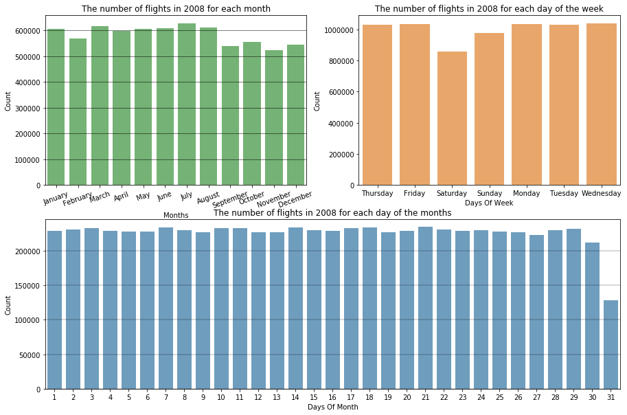

```python
# plotting
plt.figure(figsize=(15,10))
color = sb.color_palette()

plt.subplot(2,2,1)
countplot_func(df, 'Month', 2);
plt.grid(axis='y', linewidth = 0.5, color= 'black')
plt.xticks(rotation = 20)
plt.xlabel('Months')
plt.ylabel('Count')
plt.title('The number of flights in 2008 for each month')

plt.subplot(2,2,2)
countplot_func(df, 'DayOfWeek', 1);
plt.xlabel('Days Of Week')
plt.ylabel('Count')
plt.title('The number of flights in 2008 for each day of the week')

plt.subplot(2,1,2)
countplot_func(df, 'DayofMonth', 0);
plt.grid(axis='y', linewidth = 0.3, color= 'black');
plt.xlabel('Days Of Month');
plt.ylabel('Count')
plt.title('The number of flights in 2008 for each day of the months');
```

*I created a bar charts for months, day of weeks and day of months, since the first two are a categorical variables.*

*These charts are uniformly distributed apart from some drops in each graph. Еhe last graph shows that on every day of any month, approximately the same number of flights takes place, not counting the 30th and 31st. This is due to the alternation of 30 and 31 numbers and also due to leap and common years. As for the days of the week and months, the smallest number of flights takes place on weekends and on last four months of the year.*

# II

```python
# plotting
def flight_distance_distr():
    plt.figure(figsize=(8,5))
    color = sb.color_palette()

    sb.distplot(df['Distance'], color=color[7], kde=False);
    plt.xscale('log')
    ticks = [10, 20, 60, 100, 200, 600, 1000, 2000, 6000]
    plt.xticks(ticks, ticks)
    plt.grid(axis='x');
    plt.title('Airplane flight distance distribution')
    plt.xlabel('Distance(miles)')
    plt.ylabel('Count');
```

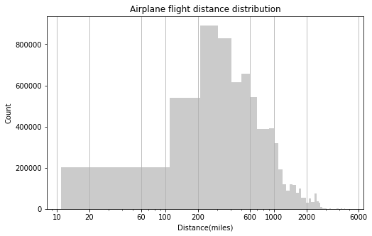

```python
flight_distance_distr();
```

*I created a histogram for distance, since it is a numeric variable. My initial plots show that distance follows a highly right-skewed distribution, because of this I used a log scaling. Under a log scale, i see that the data is roughtly unimodal, with one large peak somewhere between 200 and 300.*

# III

```python
# setting data order
cancellation_code = ['A','B','C','D']
order = pd.api.types.CategoricalDtype(categories=cancellation_code, ordered=True)
df['CancellationCode'] = df['CancellationCode'].astype(order);
```

```python
# plotting
def canceled_flights_distr():
    plt.figure(figsize=(6,5))
    ax = sb.countplot(data=df, x= 'CancellationCode', hue = 'CancellationCode', alpha = 0.7, dodge = False);
    plt.grid(axis='y', linewidth = 0.15, color = 'black');
    plt.ylabel('Count')
    plt.xlabel('Cancellation Code');
    plt.title('Distribution of canceled flights for reasons.');
    ax.legend(['Carrier','Weather ','NAS', 'Security']);
```

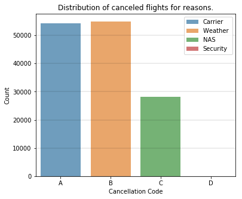

```python
canceled_flights_distr();
```

*Since these features are categorical, i produced bar chart here. In addition, since the columns are not ordinal, i sorted them alphabetically.*

*The bar chart show that the main reason for cancellations is weather. After a little lag, cancellations due to carrier follows. It may seem that the last variable(security) is missing on the graph, but due to its very small value, it is not visible. Below I have provided statistics on the number of cancellations. It can be seen that the difference is huge.*

```python
df.CancellationCode.value_counts()
```

```
B    54904
A    54330
C    28188
D       12
Name: CancellationCode, dtype: int64
```

### Of the features you investigated, were there any unusual distributions? Did you perform any operations on the data to tidy, adjust, or change the form of the data? If so, why did you do this?

> I have deleted almost half of the columns in this dataset that I will not be using in this analysis. Also I figured that I would not change the data type for the date to make it easier for me to compose visualizations in the future.

> Сhanged the numeric data of months and days of the week to verbal data.

## Bivariate Exploration

In the second part of the analysis, I will look at visualizations with two variables(bivariate exploration). Here we will look at the relationship between two variables depending on their type. I asked the following questions:

> At which airports the most frequent flight cancellations occur?

> Is there a relationship between the departure time of the aircraft and the distance?

> how canceled flights were distributed by months?

# IV

```python
most_cancell = df.groupby('Origin', as_index = False).count()[['Origin', 'CancellationCode']].sort_values(by = 'CancellationCode', ascending = False)
least_cancel = df.groupby('Origin', as_index = False).count()[['Origin', 'CancellationCode']].sort_values(by = 'CancellationCode', ascending = True)
```

```python
# creating a function to avoid repetition during visualizations.
def barplot_func(df, top_air):
    return sb.barplot(data = df.head(top_air), x = 'CancellationCode', y = 'Origin', color = color1)
```

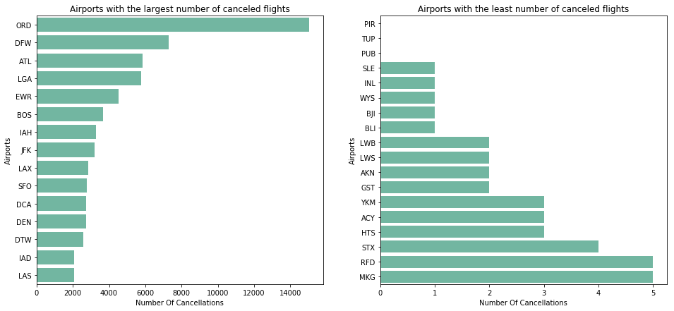

```python
# plotting
plt.figure(figsize=(16,7))
color1 = sb.color_palette("Set2")[0]

plt.subplot(1,2,1)
barplot_func(most_cancell, 15);
plt.title('Airports with the largest number of canceled flights');
plt.ylabel('Airports')
plt.xlabel('Number Of Cancellations')


plt.subplot(1,2,2)
barplot_func(least_cancel, 18);
plt.title('Airports with the least number of canceled flights');
plt.ylabel('Airports');
plt.xlabel('Number Of Cancellations');
```

*I created a bar chart here, since i have one categorical and one quantitative variable, where each categorical data has a corresponding number.*

# V

```python
# plotting
def distr_flight_distan_dep_time():
    plt.figure(figsize=(8,5))
    sb.regplot(data=df.head(10000), x= 'CRSDepTime', y = 'Distance', scatter_kws={'alpha':0.1});
    plt.title('Distribution between flight distance and departure time.');
    plt.xlabel('CRS Departure Time');
```

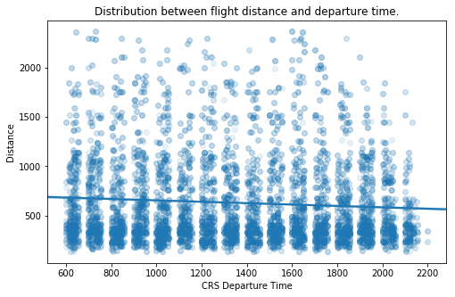

```python
distr_flight_distan_dep_time()
```

*Since these are both numeric variables, i created a scatterplot.*

# VI

**First method**

```python
# plotting
def distr_canceled_flights_by_month1():
    g = sb.FacetGrid(data=df, col='Month', col_wrap=4)
    g.map(sb.countplot, 'CancellationCode', palette = ['#ffef96', '#80ced6', '#f57c61', '#82b74b']);
```

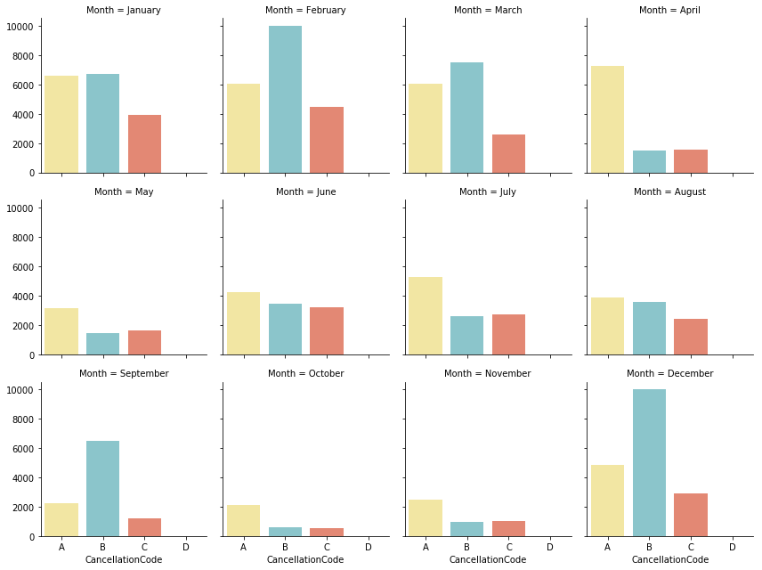

```python
distr_canceled_flights_by_month1();
```

**Second method**

```python
# plotting
def distr_canceled_flights_by_month2():
    plt.figure(figsize=(15,6))
    a = sb.color_palette("tab10")

    ax = sb.countplot(data = df, x = 'Month', hue = 'CancellationCode', palette = ['#ffef96', '#80ced6', '#f57c61', '#82b74b'])
    plt.grid(axis='y', linewidth = 0.15, color = 'black');
    ax.legend(['Carrier','Weather ','NAS', 'Security'], loc = 'upper center');
    plt.title('Distribution of canceled flights for reasons by month');
    plt.ylabel('Count');
    plt.xlabel('Months');
```

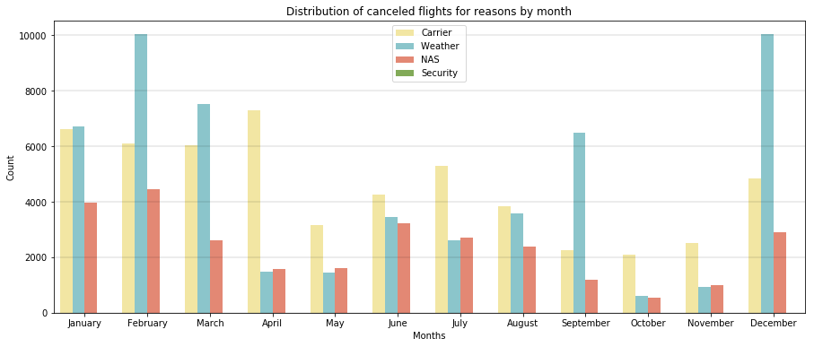

```python
distr_canceled_flights_by_month2();
```

*Since these features are categorical, i produced bar chart here.*

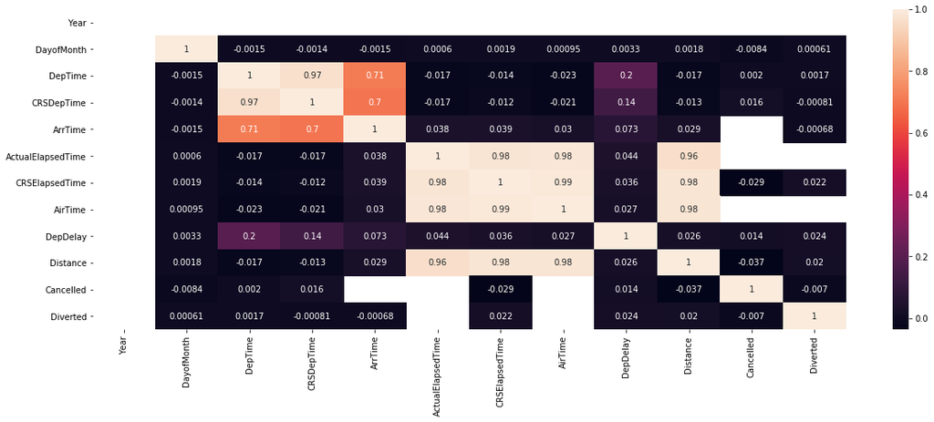

```python
plt.figure(figsize=(20,7))
sb.heatmap(df.corr(), annot=True);
```

### Talk about some of the relationships you observed in this part of the investigation. How did the feature(s) of interest vary with other features in the dataset?

> In first graphs i considered airports with higher and lower rates of cancelled flights. Flights were canceled due to carrier(A), weather(B), NAS(C)(https://aspmhelp.faa.gov/index/Types_of_Delay.html - info about NAS) and security(D). By a huge margin in the list of the most frequent canceled flights is the airport Chicago O'Hare International Airport(15000 canceled flights). It is followed by Dallas Fort Worth International Airport(7500) and Hartsfield – Jackson Atlanta International Airport(5800).

> In the following graph, I examined the relationship between distance and scheduled departure time. I wanted to know if the departure time(morning, afternoon, evening, night) of the plane depends on the distance. Having received the results, i realized that there is no connection between them and the distance does not depend on what time the plane takes off.

> In the last graph I wanted to know the distribution of the flight cancellation because of weather in each month. As expected, the most frequent flight cancellations occur in winter (December and February). Starting from April and until the end of the summer, flight cancellations due to weather are more moderate. Surprisingly, the least number of flight cancellations due to weather was observed in two out of three months of autumn. To make the visualization more informative, i also added the rest of the reasons for the cancellation of flights.

### Did you observe any interesting relationships between the other features (not the main feature(s) of interest)?

> At the very end, I created a heatmap of the relationships of all variables.

## Multivariate Exploration

In the third part of the analysis, I will look at visualizations with three and more variables(multivariate exploration). In this part there will be more complex visualizations, more informative graphs. This is where encodings come in with the help of color, size and shape. I asked the following questions:

> What is the relationship between the departure, arrival of the aircraft and the distance it travels?

> What days are the most frequent departure delays in average (in minutes)?

> Which days and which flights were most often redirected?

> What the heatmap will look like for delayed flights (average in minutes) by months in the top 20 airports by this indicator?

# VII

```python
# plotting
def distr_dep_time_arr_time_distance():
    sample = df.sample(700)
    plt.figure(figsize=(15,5))
    ax = sb.regplot(data=sample, x='DepTime', y= 'ArrTime', marker='o',
               scatter_kws={'s': df['AirTime'], 'alpha':0.1}, fit_reg=False, x_jitter=0.04);
    plt.title('Distribution between departure time, arrival time and distance');
    plt.ylabel('Arrival Time');
    plt.xlabel('Departure Time');
```

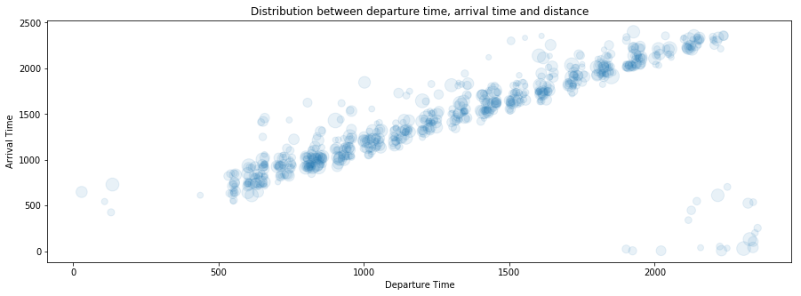

```python
distr_dep_time_arr_time_distance();
```

*Since these are both numeric variables, i choise a scatterplot.*

# VIII

```python
# setting data order
d_of_week = ['Monday', 'Tuesday', 'Wednesday', 'Thursday', 'Friday', 'Saturday', 'Sunday']
order = pd.api.types.CategoricalDtype(categories=d_of_week, ordered=True)
df['DayOfWeek'] = df['DayOfWeek'].astype(order);
```

```python
# plotting
def distr_dep_delay_arr_time_distance():
    g = sb.FacetGrid(data=df, col='Month', col_wrap=4)
    g.map(sb.barplot, 'DayOfWeek', 'DepDelay', palette = ['#FF0000','#FF8000','#FFFF00', '#008000', '#0000ff', '#4b0082', '#ee82ee']);
    g.set_xticklabels(rotation = 70);
    g.set_xlabels('Day Of Week')
    g.set_ylabels('Departure Delay')
    g.fig.subplots_adjust(top=0.85)
    g.fig.suptitle('Distribution between departure delay, arrival time and distance');
```

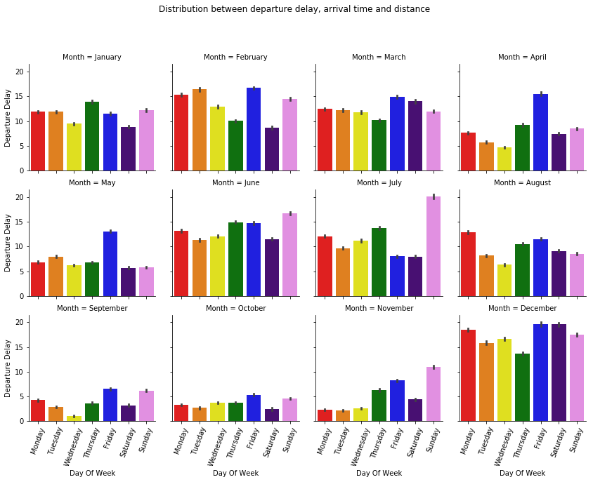

```python
distr_dep_delay_arr_time_distance();
```

# IX

```python
# concatenation of two columns into one to get flight directions
df['Flight'] = df['Origin']+ '-' + df['Dest']
div_flights = df[df.Diverted == 1]
div_flights_top = div_flights.groupby(['Flight'], as_index = False).count()[['Flight', 'Diverted']].sort_values(by = ['Diverted'], ascending = False)
div_flights_top = div_flights_top.head(30)
div_flights_top_df = div_flights[div_flights.Flight.isin(div_flights_top.Flight)]
```

```python
# plotting
def distr_flights_divertedflights_day_of_week():
    g=sb.FacetGrid(data=div_flights_top_df, col='Flight', col_wrap=5)
    g.map(sb.countplot, 'DayOfWeek')
    g.set_xticklabels(rotation = 70)
    g.fig.subplots_adjust(top=0.85)
    g.fig.suptitle('Distribution between flights, diverted flights and day of week');
```

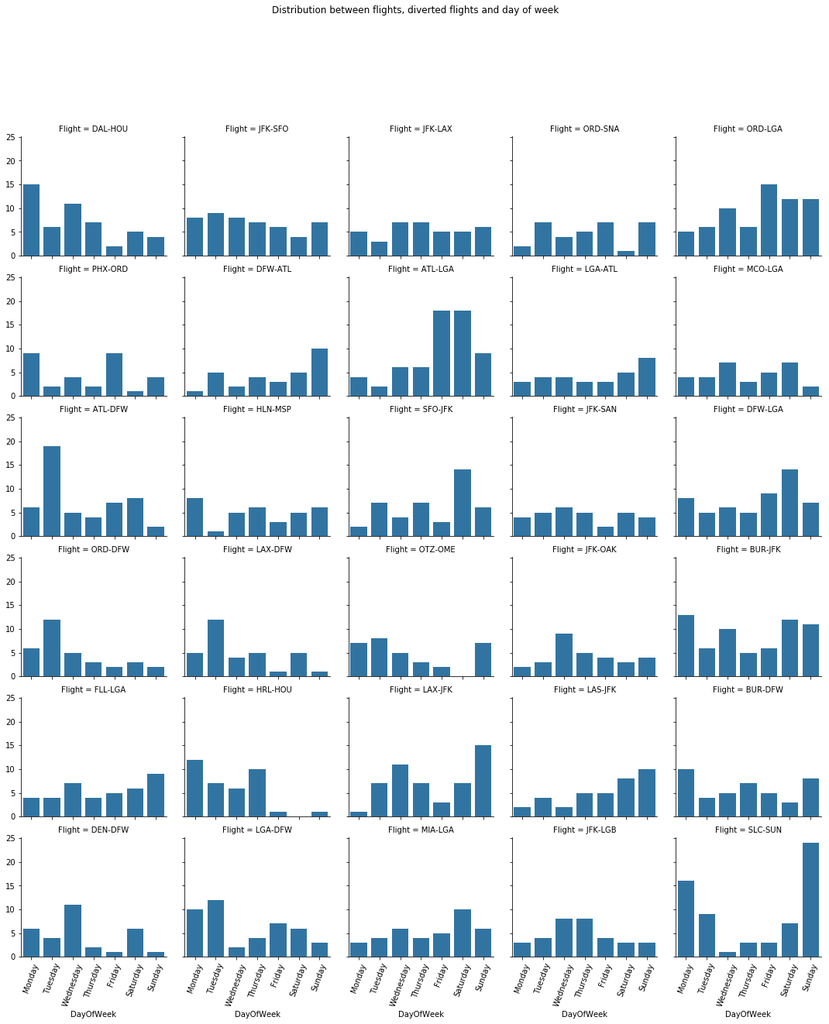

```python
distr_flights_divertedflights_day_of_week();
```

# X

```python
# preparing a dataframe for using a heatmap
airpor_delay_20 = df.groupby(['Origin']).mean()['DepDelay'].sort_values(ascending=False)[:20].index
airpor_delay_20_df = df[df.Origin.isin(airpor_delay_20)]
delay_means = airpor_delay_20_df.groupby(['Origin', 'Month']).mean()['DepDelay']
delay_means = delay_means.reset_index(name='ArrDelay_avg')
delay_means_pivot = delay_means.pivot(index='Origin', columns='Month', values='ArrDelay_avg')
```

```python
# plotting
def dep_delay_by_Origin_and_Month():
    plt.figure(figsize=[14,12])
    sb.heatmap(delay_means_pivot, cmap='mako_r', annot=True, fmt='0.3f', cbar_kws={'label':'Average Departure Delay (minutes)'});
    plt.title('Departure Delay Time by Origin(IATA airport code) and Month')
    plt.ylabel('Airport code');
```

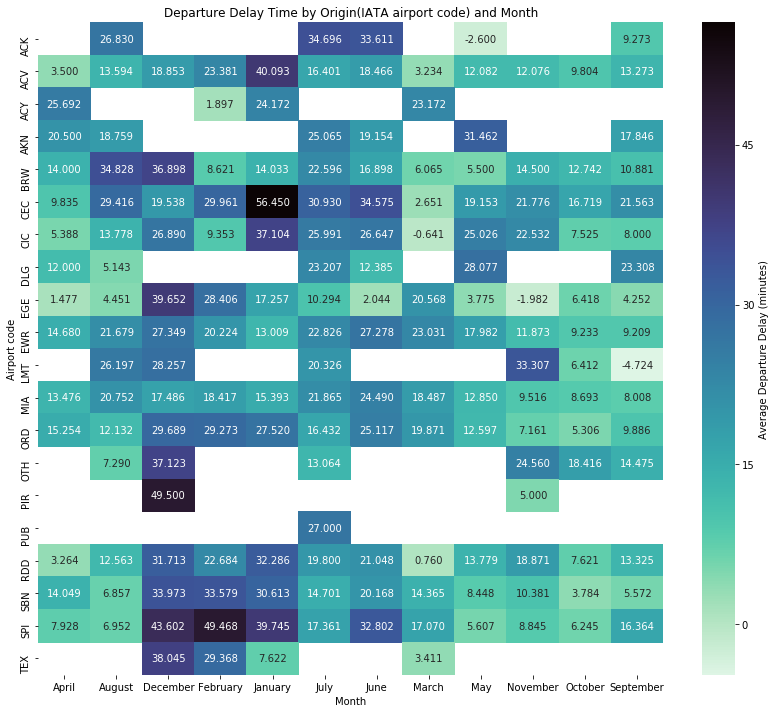

```python
dep_delay_by_Origin_and_Month();
```

### Talk about some of the relationships you observed in this part of the investigation. Were there features that strengthened each other in terms of looking at your feature(s) of interest?

> In the first visualization, data show an uphill pattern as you move from left to right, this indicates a positive relationship between X and Y. As the X-values increase, the Y-values tend to increase. I looked at the relationship between departure, arrival and distance traveled. The data in the lower right corner may appear to be outliers, but it is not. The reason for this is that the plane took off in the evening and landed the very next day.

> In the second graph, i looked at departure delays in minutes for each day of the week throughout the year. As you can see from the visualization, the months with the highest number of departure delays coincide with the months with the highest number of canceled flights. This makes sense because the months with the most canceled flights will roughly be the months with the most departure delays.

> In the last visualization, i looked at the time of the delay in the departure of the plane(top 20 airports for this indicator) and the airport of departure by months. To accomplish this I used a heatmap. On this heat map, light areas represent less time spent, while dark areas represent more time. You can see that at some airports, delays were only a few months, but due to their magnitude, they hit the top twenty. More than half of the airports experience delays every month on average. Top 3 longest delays seen in Winter.